# QTM 350 - Data Science Computing

Lecture 13 - Python Data Types, Boolean Logic, and Control Structures

Danilo Freire

Emory University

16 October, 2024

# Nice to see you all again! How was the break? 🍂

# Brief recap of last class 📚

## What did we learn?

- We have learned a lot of things so far! 🤓
- Command line, Git, GitHub, Quarto, AI tools, and more! 💻
- We are now ready to start learning a bit of Python! 🐍
- We will have three sessions on Python
- Many of you are already familiar with Python, so this will be a review for you
- For those who are not, don’t worry! We will start from the basics! 😉
- Let’s get started! 🚀

## Installing Python - Anaconda

- There are several ways to [install Python](https://www.python.org/downloads/)
- I recommend that you install [Anaconda](https://www.anaconda.com/products/distribution)
- It is free, well-maintained, and comes with many useful packages for data science
- You can install it on Windows, Mac, and Linux
- Follow the instructions on the website
- Our course website has a detailed guide on installing Anaconda and integrating it with VSCode. [You can find the tutorial here](https://danilofreire.github.io/qtm350/tutorials/01-vscode-anaconda-tutorial.html). Feel free to check it out! 📚
- If you have any questions, let me know! 😉

[figure not shown]

https://www.anaconda.com/download

## Python basics

- Python is a high-level, interpreted, and general-purpose programming language
- It is widely used in data science, machine learning, web development, and more
- We will use it in this course to analyse data, interact with SQL databases, and parallel computing
- Python is known for its simplicity and readability

```python
print("Hello, world!")
```

```
Hello, world!
```

- There are also thousands of libraries available for Python, such as [NumPy](https://numpy.org/), [Pandas](https://pandas.pydata.org/), [Matplotlib](https://matplotlib.org/), and [Scikit-learn](https://scikit-learn.org/), which are widely used in data science
- Python is an [object-oriented](https://realpython.com/python3-object-oriented-programming/) language, which means that everything in Python is an object (e.g., variables, functions, classes)
- Objects can be manipulated, and they have attributes and methods
- Python is also a dynamically typed language, which means that you don’t need to declare the type of a variable before using it
- Python is famous for its [somewhat idyosincratic syntax](https://python.plainenglish.io/10-quirks-and-idiosyncrasies-of-python-c7a6c1ed51d5), which includes [using indentation (4 spaces) to define code blocks](https://note.nkmk.me/en/python-indentation-usage/), [zero-based indexing](https://python-history.blogspot.com/2013/10/why-python-uses-0-based-indexing.html), and [unconventional slicing notation](https://stackoverflow.com/questions/509211/understanding-slice-notation)

```python
# Space indentation
if 5 > 2:
    print("Five is greater than two!")
```

[output not shown]

```python
# Slicing notation
a = "Hello, World!"
print(a[2:5])
```

```
llo
```

## Python data types

- Python has several built-in data types, with the most common being:
  - `int` (integer): whole numbers (e.g., 1, 2, 3)
  - `float` (floating-point number): numbers with decimal points (e.g., 1.0, 2.5, 3.14)
  - `str` (string): text (e.g., “Hello, world!”)
  - `bool` (boolean): logical values (e.g., True, False)
  - `list`: ordered, mutable collection of items (e.g., [1, 2, 3])
  - `tuple`: ordered, immutable collection of items (e.g., (1, 2, 3))
  - `dict` (dictionary): unordered collection of key-value pairs (e.g., {“name”: “Alice”, “age”: 25})
  - `set`: unordered collection of unique items (e.g., {1, 2, 3})
- You can check the type of a variable using the `type()` function

```python
x = 5
print(type(x))
```

```
<class 'int'>
```

- You can convert between data types using the `int()`, `float()`, `str()`, `bool()`, `list()`, `tuple()`, `dict()`, and `set()` functions

```python
x = 5
y = float(x)
print(y)
```

```
5.0
```

## Variables and values in Python

- Values: pieces of data a computer programme works with
  - Examples: numbers (42), text (“Hello!”)
  - Different types: integers, strings, etc.
- Variables: names that refer to values
  - In maths/stats: often `x`, `y`
  - In Python: more descriptive names possible: `age`, `name`, etc
- Variable naming rules:
  - Must start with a letter or underscore
  - Can include letters, numbers, underscores
  - Cannot be Python reserved words (e.g. `for`, `while`, `class`)
  - Case-sensitive (`myVar` ≠ `myvar`)
- Think of variables as boxes holding information
  - Can contain single numbers, vectors, strings, etc

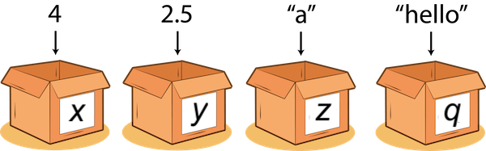

- Use assignment operator (`=`) to assign values to variables
  - Example: `x = 42`
- Best practices for variable names:
  - Use descriptive names
  - Avoid overwriting built-in functions or keywords

## Arithmetic operators

- Python supports several arithmetic operators, including:
  - `+` (addition)
  - `-` (subtraction)
  - `*` (multiplication)
  - `/` (division)
  - `//` (floor division)
  - `%` (modulus)
  - `**` (exponentiation)
- Let’s have a go at applying these operators to numeric types and observe the results

```python
1 + 2 + 3 + 4 + 5  # add
```

```
15
```

```python
2 * 3.14159  # multiply
```

```
6.28318
```

```python
2 ** 10  # exponent
```

```
1024
```

- Division may produce a different `dtype` than expected, it will change `int` to `float`

```python
int_2 = 2
type(int_2)
type(int_2 / int_2)
```

```
float
```

```python
int(101 / 2)
```

```
50
```

- The `%` “modulus” operator gives us the remainder after division

```python
101 % 2
```

```
1
```

## None

- `None` is a special constant in Python that represents the absence of a value
- It is often used to represent missing data or as a placeholder

```python
x = None
print(x)
```

```
None
```

```python
type(x)
```

```
NoneType
```

- `None` works with complex data types as well

```python
x = [None, 2, 3]

for i in x:
    print(i)
```

```
None
2
3
```

## Strings

- Text is stored as a data type called a `string`
- We can think of a string as a sequence of characters
- Strings can be enclosed in single quotes (`'...'`) or double quotes (`"..."`)

```python
x = "Hello, world!"
print(x)
```

```
Hello, world!
```

```python
y = 'Hello, world!'
print(y)
```

```
Hello, world!
```

- There’s no difference between the two methods, but there are cases where having both is useful!
- We also have triple double quotes, which are typically used for function documentation, e.g., `"""This function adds two numbers"""`
- If the string contains a quotation or apostrophe, we can use a combination of single and double quotes to define the string

```python
z = "Alice's cat"
print(z)
```

```
Alice's cat
```

```python
quote = 'Donald Knuth: "Premature optimisation is the root of all evil."'
quote
```

```
'Donald Knuth: "Premature optimisation is the root of all evil."'
```

## Boolean logic

- Boolean logic is a branch of algebra that deals with true and false values
- In Python, we have two boolean values: `True` and `False`

```python
the_truth = True
the_truth
```

```
True
```

```python
type(the_truth)
```

```
bool
```

```python
lies = False
lies
```

```
False
```

```python
type(lies)
```

```
bool
```

## Comparison operators

- We can use boolean operators to compare values and return boolean values
- The main boolean operators are:
  - `==` (equal)
  - `!=` (not equal)
  - `>` (greater than)
  - `<` (less than)
  - `>=` (greater than or equal to)
  - `<=` (less than or equal to)
  - `is` (identity)
  - `not` (negation)
  - `in` (membership)
- Some examples

```python
2 < 3
```

```
True
```

```python
"AI" == "Solve all the world's problems"
```

```
False
```

```python
2 != "2"
```

```
True
```

```python
2 == 2.0
```

```
True
```

```python
2 is 2
```

```
True
```

```python
2 is not 3
```

```
True
```

```python
"AI" in "AI will solve all the world's problems"
```

```
True
```

## Boolean operators

- We can combine boolean values using boolean operators
- The main boolean operators are:
  - `and` (logical and)
  - `or` (logical or)
  - `not` (logical not)
- The `and` operator returns `True` if both operands are `True`
- The `or` operator returns `True` if at least one operand is `True`
- The `not` operator returns `True` if the operand is `False`
- Some examples

```python
True and True
```

```
True
```

```python
True and False
```

```
False
```

```python
True or False
```

```
True
```

```python
not True
```

```
False
```

```python
not not True
```

```
True
```

```python
("Python 2" != "Python 3") and (2 <= 3)
```

```
True
```

## Lists and tuples

- Lists and tuples are ordered collections of items
- Lists are mutable, while tuples are immutable
- We will start with lists
- Lists are defined using square brackets (`[]`)

```python
my_list = [1, 2, "THREE", 4, 0.5]
my_list
```

```
[1, 2, 'THREE', 4, 0.5]
```

```python
type(my_list)
```

```
list
```

- Lists can hold any datatype - even other lists!

```python
another_list = [1, "two", [3, 4, "five"], True, None, {"key": "value"}]
another_list
```

```
[1, 'two', [3, 4, 'five'], True, None, {'key': 'value'}]
```

- You can get the length of a list using the `len()` function

```python
len(another_list)
```

```
6
```

- Tuples look similar to lists, but they are defined using parentheses (`()`) and are immutable
- Tuples are often used to store related pieces of information, such as coordinates

```python
today = (1, 2, "THREE", 4, 0.5)
today
```

```
(1, 2, 'THREE', 4, 0.5)
```

```python
type(today)
```

```
tuple
```

```python
len(today)
```

```
5
```

## Indexing and slicing

- We can access individual items in a list or tuple using indexing
- Indexing starts at 0
- We can also access multiple items using slicing
- Slicing uses the syntax `start:stop:step`

```python
my_list = [1, 2, "THREE", 4, 0.5]
my_list[0]
```

```
1
```

```python
my_list[2]
```

```
'THREE'
```

```python
my_list[-1]
```

```
0.5
```

```python
my_list[1:3]
```

```
[2, 'THREE']
```

- Note from the above that the start of the slice is inclusive and the end is exclusive
- So `my_list[1:3]` fetches elements 1 and 2, but not 3
- Strings behave the same as lists and tuples when it comes to indexing and slicing
- Remember, we think of them as a sequence of characters

```python
alphabet = "abcdefghijklmnopqrstuvwxyz"
alphabet[0]
```

```
'a'
```

```python
alphabet[1:3]
```

```
'bc'
```

```python
alphabet[-1]
```

```
'z'
```

```python
alphabet[:5]
```

```
'abcde'
```

## List methods

- Lists have several methods that allow us to manipulate them
- Some common methods include:
  - `append()`: add an item to the end of the list
  - `insert()`: add an item at a specific position
  - `remove()`: remove an item by value
  - `pop()`: remove an item by index
  - `reverse()`: reverse the list
- Let’s see some examples

```python
my_list = [1, 2, "THREE", 4, 0.5]
my_list.append("six")
my_list
```

```
[1, 2, 'THREE', 4, 0.5, 'six']
```

```python
my_list.insert(2, "two")
my_list
```

```
[1, 2, 'two', 'THREE', 4, 0.5, 'six']
```

```python
my_list.remove("two")
my_list
```

```
[1, 2, 'THREE', 4, 0.5, 'six']
```

```python
my_list.pop(2)
my_list
```

```
[1, 2, 4, 0.5, 'six']
```

```python
my_list.reverse()
my_list
```

```
['six', 0.5, 4, 2, 1]
```

## Sets

- Sets are unordered collections of unique items
- Sets are defined using curly braces (`{}`)
- Sets do not allow duplicates
- We can perform set operations, such as union, intersection, and difference
- Sets are mutable, but their items must be immutable
- We can convert lists to sets using the `set()` function
- Some examples

```python
my_set = {1, 2, 3, 4, 5}
my_set
```

```
{1, 2, 3, 4, 5}
```

```python
my_set.add(6)
my_set
```

```
{1, 2, 3, 4, 5, 6}
```

```python
my_set.add(6)
my_set
```

```
{1, 2, 3, 4, 5, 6}
```

```python
my_list = [1, 2, 3, 4, 5, 5]
my_set = set(my_list)
my_set
```

```
{1, 2, 3, 4, 5}
```

```python
my_set2 = {4, 5, 6, 7, 8}
my_set.union(my_set2)
```

```
{1, 2, 3, 4, 5, 6, 7, 8}
```

```python
my_set.intersection(my_set2)
```

```
{4, 5}
```

## String methods

- Strings also have several methods for manipulation
- Some common methods include:
  - `upper()`: convert to uppercase
  - `lower()`: convert to lowercase
  - `strip()`: remove leading and trailing whitespace
  - `replace()`: replace a substring
  - `split()`: split the string into a list
- Let’s see some examples
- Note that strings are immutable, so these methods return new strings
- The original string is not modified

```python
x = " Hello, world! "
x.upper()
```

```
' HELLO, WORLD! '
```

```python
x.lower()
```

```
' hello, world! '
```

```python
x.strip()
```

```
'Hello, world!'
```

```python
x.replace("world", "Python")
```

```
' Hello, Python! '
```

```python
x.split(",")
```

```
[' Hello', ' world! ']
```

```python
x.strip().split(" ") # chaining methods
```

```
['Hello,', 'world!']
```

## String formatting

- Python has ways of creating strings by “filling in the blanks” and formatting them nicely
- This is helpful for when you want to print statements that include variables or statements
- There are a few ways of doing this but I use and recommend `f-strings` which were introduced in Python 3.6
- All you need to do is put the letter `f` out the front of your string and then you can include variables with curly-bracket notation `{}`

```python
name = "Alice"
age = 25
f"My name is {name} and I am {age} years old."
```

```
'My name is Alice and I am 25 years old.'
```

```python
name = "Newborn Baby"
age = 4 / 12
day = 20
month = 3
year = 2020
template_new = f"Hello, my name is {name}. I am {age:.2f} years old. I was born on {day}/{month:02}/{year}."
template_new
```

```
'Hello, my name is Newborn Baby. I am 0.33 years old. I was born on 20/03/2020.'
```

- The `:.2f` notation is a way of formatting the number to two decimal places
- The `:02` notation is a way of formatting the number to two digits, with leading zeros if necessary
- More on string formatting [here](https://docs.python.org/3.4/library/string.html#format-specification-mini-language)

## Dictionaries

- Dictionaries are unordered collections of key-value pairs
- Dictionaries are defined using curly braces (`{}`)
- We can access values using keys
- Dictionaries are mutable
- We can convert lists of tuples to dictionaries using the `dict()` function

```python
my_dict = {"name": "Alice",
           "age": 25,
           "city": "Atlanta"}
my_dict
```

```
{'name': 'Alice', 'age': 25, 'city': 'Atlanta'}
```

```python
my_dict["name"]
```

```
'Alice'
```

```python
my_dict["age"]
```

```
25
```

```python
my_dict["city"]
```

```
'Atlanta'
```

```python
my_dict["city"] = "New York"
my_dict
```

```
{'name': 'Alice', 'age': 25, 'city': 'New York'}
```

```python
my_dict["country"] = "USA"
my_dict
```

```
{'name': 'Alice', 'age': 25, 'city': 'New York', 'country': 'USA'}
```

```python
my_dict.keys()
```

```
dict_keys(['name', 'age', 'city', 'country'])
```

```python
my_dict.values()
```

```
dict_values(['Alice', 25, 'New York', 'USA'])
```

## Empties

```python
empty_list = []
print(empty_list)
```

```
[]
```

```python
empty_list = list()
print(empty_list)
```

```
[]
```

```python
empty_dict = {}
print(empty_dict)
```

```
{}
```

```python
empty_dict = dict()
print(empty_dict)
```

```
{}
```

- You get the idea! 😉

# Conditional statements 🚦

## Conditional statements

### If, elif, else

- Conditional statements allow us to execute different blocks of code based on whether a condition is `True` or `False`
- The main conditional statements in Python are:
  - `if`: execute a block of code if a condition is `True`
  - `elif`: execute a block of code if the previous condition is `False` and the current condition is `True`
  - `else`: execute a block of code if all previous conditions are `False`
  - The syntax is `if condition:`
  - The code block is defined by indentation
  - You can have multiple `elif` statements
  - You can have zero or one `else` statement

## If statements

[figure not shown]

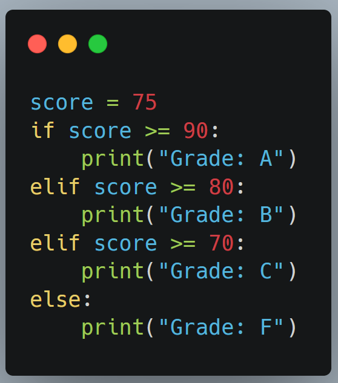

## If statements

- Let’s see an example

```python
name = "Danilo"

if name.lower() == "danilo":
    print("That's my name too!")
elif name.lower() == "juan":
    print("That's a nice name!")
else:
    print(f"Hello {name}! That's a cool name!")
print("Nice to meet you!")
```

```
That's my name too!
Nice to meet you!
```

- Note that the `elif` and `else` blocks are optional
- You can have as many `elif` blocks as you want
- The `if` statement evaluates the condition `name.lower() == "danilo"`
- If the condition is `True`, the code block under the `if` statement is executed
- If the condition is `False`, the code block under the `elif` statement is executed
- If all conditions are `False`, the code block under the `else` statement is executed
- The code block is defined by indentation (4 spaces)
- The `print("Nice to meet you!")` statement is executed regardless of the condition

```python
name = "David"

if name.lower() == "danilo":
    print("That's my name too!")
elif name.lower() == "juan":
    print("That's a nice name!")
else:
    print(f"Hello {name}! That's a cool name!")
print("Nice to meet you!")
```

```
Hello David! That's a cool name!
Nice to meet you!
```

## Nested if statements

- You can nest `if` statements inside other `if` statements
- This allows you to create more complex conditions
- The code block is defined by indentation, as usual

```python
name = "Danilo"
age = 42

if name.lower() == "danilo":
    if age >= 18:
        print("Welcome, Danilo! You are an adult!")
    else:
        print("Welcome, Danilo! You are a minor!")
else:
    print(f"Hello {name}!")
```

```
Welcome, Danilo! You are an adult!
```

## Inline if statements

- You can use inline `if` statements to execute a single line of code based on a condition
- The syntax is `value = true_value if condition else false_value`

```python
words = ["the", "list", "of", "words"]

x = "long list" if len(words) > 10 else "short list"
x
```

```
'short list'
```

- The code is equivalent to

```python
words = ["the", "list", "of", "words"]

if len(words) > 10:
    x = "long list"
else:
    x = "short list"
x
```

```
'short list'
```

## Truth value testing

- In Python, any object can be tested for truth value
- The following objects are considered `False`:
  - `None`
  - `False`
  - Zero of any numeric type (e.g., `0`, `0.0`, `0j`)
  - Empty sequences (e.g., `[]`, `()`, `{}`, `""`)
  - Empty sets and dictionaries
- All other objects are considered `True`
- This is useful when you want to check if a variable is empty, such as when you perform some data cleaning and want to remove missing values
- Let’s see some examples using `if` statements

```python
x = 0

if x:
    print("True")
else:
    print("False")
```

```
False
```

```python
x = 1

if x:
    print("True")
else:
    print("False")
```

```
True
```

# For loops 🔄

## For loops

- For loops allow us to iterate over a sequence of items

```python
for n in [2, 7, -1, 5]:
    print(f"The number is {n} and its square is {n**2}")
print("I'm outside the loop!")
```

```
The number is 2 and its square is 4
The number is 7 and its square is 49
The number is -1 and its square is 1
The number is 5 and its square is 25
I'm outside the loop!
```

- The syntax is

```python
for item in sequence:
    # code block
```

- The code block is defined by indentation (4 spaces)
- The `item` variable takes on each value in the `sequence` in turn
- The `sequence` can be a list, tuple, set, dictionary, range, or string
- Colon `:` ends the first line of the loop
- The `item` variable can be any name you want

## For loops and `range()`

- A very common pattern is to use for with the `range()`
- `range()` gives you a sequence of integers up to some value (non-inclusive of the end-value) and is typically used for looping

```python
range(5)
```

```
range(0, 5)
```

```python
for i in range(5):
    print(i)
```

```
0
1
2
3
4
```

```python
for i in range(1, 6):
    print(i)
```

```
1
2
3
4
5
```

- The `range()` function can take up to three arguments: `start`, `stop`, and `step`
- The default value for `start` is `0`
- The default value for `step` is `1`
- The `stop` value is non-inclusive

```python
for i in range(1, 10, 2):
    print(i)
```

```
1
3
5
7
9
```

```python
for i in range(10, 1, -2):
    print(i)
```

```
10
8
6
4
2
```

- The `range()` function is very useful for creating loops that iterate a specific number of times

## Nested for loops

- You can nest `for` loops inside other `for` loops
- This allows you to create more complex loops or iterate over multi-dimensional data structures
- The code block is defined by indentation, as usual

```python
for x in [1, 2, 3]:
    for y in ["a", "b", "c"]:
        print((x, y))
```

```
(1, 'a')
(1, 'b')
(1, 'c')
(2, 'a')
(2, 'b')
(2, 'c')
(3, 'a')
(3, 'b')
(3, 'c')
```

- The `print((x, y))` statement is executed for each combination of `x` and `y`
- There are other clever ways of doing these kind of thing in Python
- When looping over objects, you want want to use `zip()` or `enumerate()`
- More information on these functions [here](https://realpython.com/python-enumerate/) and [here](https://realpython.com/python-zip-function/)

## `while` loops

- `while` loops allow us to execute a block of code as long as a condition is `True`
- The syntax is `while condition:`

```python
n = 10

while n > 0:
    print(n)
    n -= 1
print("Blast off!")
```

```
10
9
8
7
6
5
4
3
2
1
Blast off!
```

- The `n -= 1` statement decrements the value of `n` by 1
- The loop continues until `n` is less than or equal to 0
- Be careful with `while` loops, as they can run indefinitely if the condition is never `False`!
- You can use `break` to exit a loop prematurely

```python
n = 10

while n > 0:
    print(n)
    if n == 5:
        break
    n -= 1
print("Blast off!")
```

```
10
9
8
7
6
5
Blast off!
```

## Comprehensions

- Comprehensions are a concise way to create lists, sets, and dictionaries based on existing sequences
- List are the most common, though
- They provide a more readable and often more efficient alternative to using loops and conditional statements

```python
squares = [x**2 for x in range(10)]
squares
```

```
[0, 1, 4, 9, 16, 25, 36, 49, 64, 81]
```

- This is equivalent to

```python
squares = []
for x in range(10):
    squares.append(x**2)
squares
```

```
[0, 1, 4, 9, 16, 25, 36, 49, 64, 81]
```

- The syntax is `[expression for item in sequence]`
- You can also add an `if` statement to filter the items
- The syntax is `[expression for item in sequence if condition]`

```python
even_squares = [x**2 for x in range(10) if x % 2 == 0]
even_squares
```

```
[0, 4, 16, 36, 64]
```

- Which is equivalent to

```python
even_squares = []
for x in range(10):
    if x % 2 == 0:
        even_squares.append(x**2)
even_squares
```

```
[0, 4, 16, 36, 64]
```

# Functions 🛠️

## Functions

- Functions are the building blocks of Python programmes
- They allow you to encapsulate code and reuse it
- Functions are defined using the `def` keyword
- The syntax is `def function_name(parameters):`, then the code block (indented)

```python
def greet(name):
    return f"Hello, {name}!"

greet("Alice")
```

```
'Hello, Alice!'
```

- The `return` statement exits the function and returns a value
- The `name` variable is a parameter
- Parameters are the inputs to the function (you can have multiple parameters)
- The `greet("Alice")` statement calls the function with the argument `"Alice"`

```python
def square(n):
    n_squared = n**2
    return n_squared

square(5)
```

```
25
```

## Namespaces

- Python has several types of namespaces
- The ones that we use more often are:
  - Local namespace: variables defined inside a function
  - Global namespace: variables defined outside a function
  - Built-in namespace: variables that are built into Python (e.g., `print()`, `len()`)
- Variables defined inside a function are local to that function and cannot be accessed outside the function

```python
def cat_string(str1, str2):
    string = str1 + str2
    return string

cat_string('My name is ', 'Danilo')
```

```
'My name is Danilo'
```

```python
# print(string) # it will raise an error
```

- Global variables can be accessed inside a function
- However, you should avoid using them if possible, as it can make your code harder to read and debug

```python
## define global variable
my_var = 2
## define function
def add_two(x):
    ## references my_var
    return x + my_var

add_two(2)

## print my_var
print(my_var)
```

```
2
```

## Lambda functions

- Our last topic is lambda functions
- Lambda functions are small, anonymous functions, which are defined using the `lambda` keyword
- They are usually short and simple (only one line of code), and are sometimes used as arguments to higher-order functions

```python
add_two = lambda x: x + 2

add_two(2)
```

```
4
```

- The syntax is `lambda parameters: expression`
- You can have multiple parameters
- You can also have multiple expressions, but only one expression can be returned

```python
add = lambda x, y: x + y
print(add(3, 5))
```

```
8
```

```python
maximum = lambda x, y: x if x > y else y
print(maximum(10, 20))
```

```
20
```

# Summary 📚

## Summary

- We covered the very basics of Python programming
- We learned about data types, operators, and conditional statements
- We also learned about loops, functions, and comprehensions
- This is just the tip of the iceberg! 🐍
- Next steps: practice, practice, practice! 🤓
- Exercises available [here](https://www.w3schools.com/python/default.asp), [here](https://www.practicepython.org/), and [here](https://pychallenger.com/)
- Next class, we will review `numpy` and `pandas` 📊
- If you have any questions, feel free to ask! 🙋‍♂️

# And that’s it for today! 🎉

# Thank you for your attention! Have a great rest of your day! 🌞

[Python Intro](https://raw.githack.com/danilofreire/qtm350/main/lectures/lecture-13/13-python-intro.html)